# Cellen 2

Statistical thinking — probability distributions

Gavin Simpson

gavin@anivet.au.dk

Aarhus University

2025-03-05

## Bernoulli random variables

The simplest experiment has two outcomes; *success* or *failure*

In statistics observations such observations follow a Bernoulli distribution

If we tossed a fair coin ten times, we might observe

- Tails, Tails, Heads, Heads, Tails, Heads, Heads, Heads, Heads, Tails

Each individual trial (coin toss) is a Bernoulli random variable

## Binomial random variables

A binomial random variable is the number of successful results in $n$ independent Bernoulli trials

- Tails, Tails, Heads, Heads, Tails, Heads, Heads, Heads, Heads, Tails

We tossed the coin ten times, hence we had n = 10 trials

If we treat *Heads* as success we saw **6** successes

This number is a binomial count

## Binomial random variables

20 coin tosses, repeated 100 times

How many heads do we see in each trial?

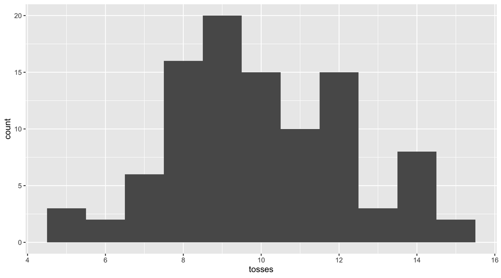

## Poisson random variables

A Poisson random variable is the number of occurrences of an event recorded in a sample of fixed area or time

Single parameter, $\lambda$, is the rate parameter or Poisson mean, the mean number of occurrences of events in each sample

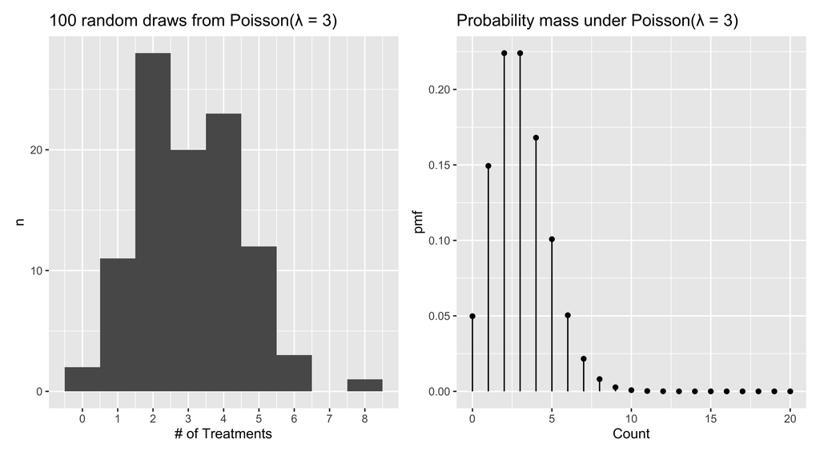

## Continuous random variables

Many environmental variables can not be described by discrete variables

Continuous random variables can take on any value, perhaps bounded by an interval with appropriate upper and lower limits

The precision of a measured value of a continuous random variable is limited by the available instrumentation

- Normal
- Log-normal
- Exponential
- Beta
- Gamma
- Student’s $t$
- $\chi^2$

## Normal random variables

Bell curve is a familiar probability distribution — known as the normal or Gaussian

Many observations clustered about the central or average value, observations extending into the tails.

- Distribution described by two parameters
  - mean ($\mu$)
  - standard deviation ($\sigma$)
- Expected value, $\mathbb{E}(y)$, is equal to $\mu$, $\mathrm{var}(y) = \sigma^2$, symmetric about $\mu$

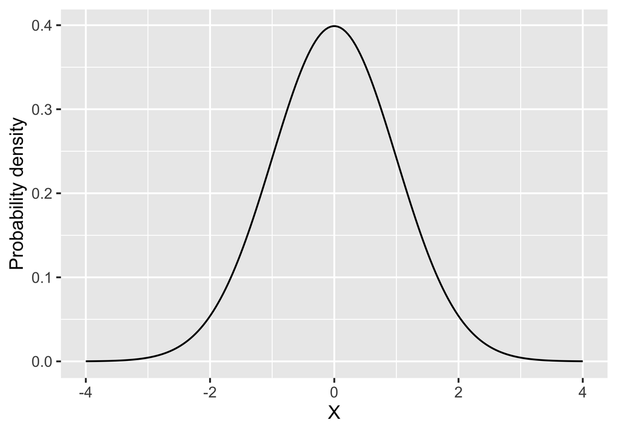

## Other continuous distributions

[figure not shown]